# ANALISIS LAND SUBSIDENCE DI JAKARTA UTARA

#PERSIAPAN LIBRARIES DAN DATA

Tahap ini merupakan proses penginstalan dan pemanggilan libraries. Proses pengunduhan data yang dibutuhkan selama proses analisis penurunan muka tanah (land subsidence) di Jakarta Utara juga di lakukan pada tahap ini

```python
# INSTALL LIIBRARIES

# Menginstal library gdown untuk mengunduh file besar langsung dari Google Drive
!pip install -q gdown

# Menginstal library fiona untuk membaca struktur dan layer di dalam File Geodatabase (GDB)
!pip install fiona -q
```

```python
# IMPORT LIBRARIES

# Mengimpor modul os untuk manajemen operasi sistem (seperti manipulasi path file)
import os

# Mengimpor geopandas untuk membaca dan mengolah data vektor (Shapefile)
import geopandas as gpd

# Mengimpor rasterio untuk membaca dan mengolah data gambar spasial (Raster/TIF)
import rasterio

# Mengimpor fungsi mask dari rasterio untuk memotong raster berdasarkan area vektor
from rasterio.mask import mask

# Mengimpor fungsi reproject dan metode Resampling dari library rasterio
from rasterio.warp import reproject, Resampling

# Mengimpor pyplot dari matplotlib untuk membuat visualisasi grafik atau peta
import matplotlib.pyplot as plt

# Mengimpor pandas untuk manipulasi data berbentuk tabel (DataFrame)
import pandas as pd

# Mengimpor numpy untuk komputasi numerik dan operasi array
import numpy as np

# Mengimpor fiona untuk membaca, menulis, dan mengelola struktur data spasial vektor (seperti layer pada File Geodatabase / GDB)
import fiona

# Mengimpor modul zipfile untuk membaca berkas arsip terkompresi (.zip)
import zipfile
```

```python
# DOWLOAD DATASET DARI GDRIVE

# Membuat folder baru bernama 'dataset' di direktori Colab; tidak akan error jika folder sudah ada (exist_ok=True)
os.makedirs("dataset", exist_ok=True)

# Membuat dictionary yang memasangkan nama file target dengan kodE (File ID) Google Drive
files = {
    "demnasgabungg.tif":
        "1JpwVTeI6qA-Q5-5NcLFUj06O_XWP-LYa",

    "S1AA_20230428T111531_20240422T111536_VVP360_INT80_G_ueF_5180_vert_disp.tif":
        "10zQFqzJxA_Nr0yCDqeqg1nNJKT-Olvh7",

    "2022_RBI25K_JAKUT.zip":
        "10uNavZnWge8gmXSk3otYEbFVb887jXug",

    "indeks_jakut.shp":
        "1pdIP_Pwt45srg-v3QqyIzD2QICiTEope",

    "indeks_jakut.dbf":
        "19lmOXaMBKpxruwLHSYGpKf6CVCWw8zFS",

    "indeks_jakut.prj":
        "1niFf6nn39rJrgJjZPXVlTCcK6ysVY3Iw",

    "indeks_jakut.shx":
        "1s46VdZEtV4AO2n-8CCOXXCat9khkJiGU",

    "data-kedalaman-muka-air-tanah-pada-sumur-pantau-di-5-wilayah-2023-komponen-data.xls":
        "1iomPFSXXdAen_ehgHB3RlDTYJJoXGKDW",

    "data-kedalaman-muka-air-tanah-pada-sumur-pantau-di-5-(lima)-wilayah-2024-komponen-data.xls":
        "1kWzMvmZB1j3fdPODGmob30daD2Iv3btg"
}

# Melakukan perulangan untuk mengambil pasangan nama file (filename) dan ID Drive (file_id) dari dictionary
for filename, file_id in files.items():
    # Menentukan path lokasi penyimpanan file hasil download di dalam folder dataset
    output = f"dataset/{filename}"

    # Mengecek apakah file tersebut belum ada di folder tujuan (menghindari download ulang file yang sama)
    if not os.path.exists(output):
        # Memanggil fungsi gdown untuk mengunduh file berdasarkan struktur URL Google Drive uc?id=
        gdown.download(
            f"https://drive.google.com/uc?id={file_id}",              # URL dinamis menggunakan File ID dari dictionary
            output,                                                   # Path lokasi penyimpanan file hasil download
            quiet=False                                               # Menampilkan progress bar/proses download di layar
        )

# Mencetak informasi status
print("Semua dataset berhasil didownload")
```

```
Semua dataset berhasil didownload
```

```python
# EKSTRAKSI DATA RBI

# Menentukan lokasi path file zip RBI Jakarta Utara yang akan diekstrak
zip_path = "dataset/2022_RBI25K_JAKUT.zip"

# Memeriksa apakah file .zip yang dituju benar-benar ada di dalam direktori
if os.path.exists(zip_path):
    # Membuka berkas arsip .zip dalam mode baca ('r' = read) sebagai variabel objek 'zip_ref'
    with zipfile.ZipFile(zip_path, "r") as zip_ref:
        # Mengekstrak seluruh isi file (File Geodatabase / GDB) ke dalam folder 'dataset'
        zip_ref.extractall("dataset")

# Mencetak informasi status
print("RBI berhasil diekstrak")
```

```
RBI berhasil diekstrak
```

#PETA LAND SUBSIDENCE JAKARTA UTARA

Output ini menampilkan distribusi spasial penurunan muka tanah (land subsidence) di Jakarta Utara berdasarkan data InSAR yang telah dipotong sesuai batas wilayah penelitian. Peta digunakan untuk mengidentifikasi lokasi-lokasi yang mengalami penurunan tanah paling signifikan serta memberikan gambaran awal mengenai pola sebaran deformasi permukaan di area studi.

```python
# MENENTUKAN PATH DATA

# Membuat variabel string untuk menyimpan alamat folder utama data lokal ('dataset')
base_path = "dataset"

# Menggabungkan nama folder utama dengan file Shapefile indeks Jakarta Utara
shp_path = os.path.join(base_path, "indeks_jakut.shp")

# Menggabungkan nama folder utama dengan file raster InSAR (.tif)
raster_path = os.path.join(
    base_path,
    "S1AA_20230428T111531_20240422T111536_VVP360_INT80_G_ueF_5180_vert_disp.tif"
)

# Menentukan string nama file baru secara langsung untuk menyimpan hasil pemotongan raster nantinya
output_raster = "insar_jakut_crop.tif"
```

```python
# CEK SISTEM KOORDINAT (CRS)

# Membuka file raster secara temporary menggunakan alias 'src'
with rasterio.open(raster_path) as src:

  # Mengambil informasi sistem koordinat (CRS) dari data raster
    raster_crs = src.crs

# Membuka file shapefile menggunakan geopandas
jakut = gpd.read_file(shp_path)

# Mencetak sistem koordinat dari data raster
print("CRS Raster:", raster_crs)

# Mencetak sistem koordinat dari variabel 'jakut' (shapefile)
print("CRS Shapefile:", jakut.crs)
```

```
CRS Raster: EPSG:32748
CRS Shapefile: EPSG:4326
```

```python
# PENYELERASAN CRS (REPROJECTION)

# Mengecek apakah sistem koordinat shapefile berbeda dengan sistem koordinat raster
if jakut.crs != raster_crs:

  # Mengubah sistem koordinat shapefile agar sama dengan sistem koordinat raster (reproyeksi
    jakut = jakut.to_crs(raster_crs)

# Mencetak hasil sistem koordinat shapefile yang terbaru setelah disamakan
print("CRS shapefile setelah disamakan:", jakut.crs)
```

```
CRS shapefile setelah disamakan: PROJCS["WGS 84 / UTM zone 48S",GEOGCS["WGS 84",DATUM["WGS_1984",SPHEROID["WGS 84",6378137,298.257223563,AUTHORITY["EPSG","7030"]],AUTHORITY["EPSG","6326"]],PRIMEM["Greenwich",0,AUTHORITY["EPSG","8901"]],UNIT["degree",0.0174532925199433,AUTHORITY["EPSG","9122"]],AUTHO…
```

```python
# MEMOTONG RASTER (CLIPPING/MASKING)

# Membuka file raster asli untuk dibaca datanya
with rasterio.open(raster_path) as src:

  # Memotong raster berdasarkan geometri shapefile dan membuang area di luarnya (crop=True)
    out_image, out_transform = mask(src, jakut.geometry, crop=True)
  # Menyalin metadata asli dari file raster untuk digunakan saat menyimpan file baru
    out_meta = src.meta.copy()
```

```python
# MENYIMPAN HASIL CROP

# Memperbarui informasi ukuran (tinggi, lebar) dan koordinat (transform) pada metadata sesuai hasil potongaN
out_meta.update({
    "driver": "GTiff", # Format file tetap GeoTIFF
    "height": out_image.shape[1], # Mengambil tinggi pixel baru dari dimensi indeks 1 array
    "width": out_image.shape[2],  # Mengambil lebar pixel baru dari dimensi indeks 2 array
    "transform": out_transform    # Memasukkan transformasi koordinat yang baru
})

# Membuat/membuka file baru di Google Drive untuk siap ditulisi data ('w' = write)
with rasterio.open(output_raster, "w", **out_meta) as dest:
    dest.write(out_image)
```

```python
# PEMBERSIHAN DATA DAN PERHITUNGAN STATISTIK

# Membuka kembali file raster baru hasil potongan yang telah disimpan sebelumnya
with rasterio.open(output_raster) as src:
    # Membaca data pixel band 1 ke dalam bentuk array numpy
    data = src.read(1)

# Memfilter data array dengan membuang pixel yang bernilai kosong/bukan data (NoData)
data = data[data != src.nodata]

# Memfilter kembali data array untuk membuang pixel yang bernilai NaN (Not a Number/error)
data = data[~np.isnan(data)]

# Mengalikan seluruh nilai pixel dengan 1000 untuk mengubah satuan meter ke milimeter (mm)
data_mm = data * 1000

# Menghitung nilai rata-rata pergeseran vertikal tanah (rata-rata subsidence)
mean_subs = np.mean(data_mm)

# Menghitung nilai minimum (angka negatif terkecil menunjukkan penurunan tanah terdalam)
max_subs = np.min(data_mm)

# Mencetak nilai rata-rata pergeseran tanah
print("Rata-rata:", mean_subs)

# Mencetak nilai penurunan tanah maksimum
print("Maksimum (subsidence terdalam):", max_subs)
```

```
Rata-rata: 11.883389
Maksimum (subsidence terdalam): -94.74525
```

```
(np.float64(-0.5), np.float64(520.5), np.float64(348.5), np.float64(-0.5))
```

[figure not shown]

```python
# VISUALISASI PETA

# Membuka file raster hasil potongan untuk proses visualisasi gambar
with rasterio.open(output_raster) as src:
    # Membaca data gambar band 1
    data = src.read(1)

# Mengatur ukuran tampilan gambar menjadi lebar 8 inci dan tinggi 6 inci
plt.figure(figsize=(8,6))

# Menampilkan array data sebagai gambar dengan gradasi warna Merah-Biru ('RdBu')
plt.imshow(data, cmap='RdBu')

# Menampilkan batang skala warna di samping peta beserta teks label satuannya
plt.colorbar(label='Vertical Displacement (mm/year)')

# Memberikan judul teks di bagian atas gambar peta
plt.title("Peta Subsidence Jakarta Utara")

# Menyembunyikan garis tepi, angka koordinat piksel, dan grid
plt.axis('off')
```

# HEATMAP ZONA RISIKO LAND SUBSIDENCE

```python
# MEMBACA DAN MEMERIKSA CRS DATA DEM

# Menggabungkan folder utama dengan nama file DEMNAS gabungan secara aman untuk membuat path file
dem_path = os.path.join(base_path, "demnasgabungg.tif")

# Membuka file raster DEM secara temporary menggunakan alias 'src'
with rasterio.open(dem_path) as src:
    # Membaca data piksel band 1 dari data DEM ke dalam array numpy
    dem = src.read(1)
    # Menyalin informasi metadata asli dari file DEM
    dem_meta = src.meta
    # Mengambil informasi sistem koordinat (CRS) milik data DEM
    dem_crs = src.crs

# Mencetak informasi sistem koordinat data DEM ke layar
print("CRS DEM:", dem_crs)
```

```
CRS DEM: EPSG:4326
```

```python
# PENYELARASAN CRS SHAPEFILE KE DEM

# Cek apakah sistem koordinat shapefile 'jakut' berbeda dengan sistem koordinat DEM
if jakut.crs != dem_crs:
    # Jika berbeda, ubah sistem koordinat shapefile mengikuti CRS milik DEM (reproyeksi)
    jakut_dem = jakut.to_crs(dem_crs)
else:
    # Jika sudah sama, gunakan shapefile asli tanpa melakukan perubahan koordinat
    jakut_dem = jakut
```

```python
# MEMOTONG RASTER DEM (ClIPPING)

# Membuka kembali file raster DEM untuk melakukan pemotongan wilayah
with rasterio.open(dem_path) as src:
    # Memotong DEM berdasarkan batas wilayah shapefile Jakarta Utara dan membuang area luarnya
    dem_crop, dem_transform = mask(src, jakut_dem.geometry, crop=True)
    # Mengambil array indeks ke-0 karena fungsi mask mengembalikan array dengan dimensi band di depan
    dem_crop = dem_crop[0]
```

```python
# RESAMPLING & REPROYEKSI DATA DEM (PENYAMAAN RESOLUSI DAN BATAS PIXEL)

# Membuka data raster InSAR (hasil crop sebelumnya) sebagai referensi target ukuran dan koordinat
with rasterio.open(output_raster) as src:
    # Membaca data piksel pergeseran tanah band 1
    insar = src.read(1)
    # Menyalin metadata milik data InSAR untuk dijadikan acuan output
    insar_meta = src.meta

# Membuat matriks kosong dengan ukuran dimensi dan tipe data (float32) yang persis sama dengan data InSAR
dem_resampled = np.empty_like(insar, dtype='float32')

# Menjalankan proses proyeksi ulang dan penyamaan ukuran (resampling) gambar raster
reproject(
    source=dem_crop,                          # Data raster asal yang akan diubah ukurannya (DEM hasil crop)
    destination=dem_resampled,                # Variabel penampung hasil resampling yang sudah dibuat sebelumnya
    src_transform=dem_transform,              # Transformasi koordinat (geotransform) asal milik DEM
    src_crs=dem_crs,                          # Sistem koordinat asal (EPSG:4326)
    dst_transform=insar_meta['transform'],    # Transformasi koordinat target (mengikuti data InSAR)
    dst_crs=insar_meta['crs'],                # Sistem koordinat target (mengikuti data InSAR yaitu EPSG:32748)
    resampling=Resampling.bilinear            # Menggunakan metode interpolasi Bilinear untuk menghaluskan piksel baru
)
```

[output not shown]

```python
# NORMALISASI (SUBSIDENCE & ELEVASI)

# Mengubah nilai subsidence menjadi positif (dikali negatif) agar nilai penurunan yang makin besar berarti makin bahaya
subs = -insar

# Melakukan normalisasi Min-Max pada data subsidence agar rentang nilainya menjadi skala 0 sampai 1
subs_norm = (subs - np.nanmin(subs)) / (np.nanmax(subs) - np.nanmin(subs))

# Menyimpan data elevasi hasil resampling ke variabel baru bernama 'elev'
elev = dem_resampled

# Melakukan normalisasi terbalik pada elevasi; semakin rendah dataran, nilainya makin mendekati 1
elev_norm = (np.nanmax(elev) - elev) / (np.nanmax(elev) - np.nanmin(elev))
```

```python
#PERHITUNGAN INDEKS RISIKO (WEIGHTED OVERLAY)

# Menentukan bobot pengaruh untuk variabel penurunan tanah (60%)
w_subs = 0.6
# Menentukan bobot pengaruh untuk variabel ketinggian/elevasi tanah (40%)
w_elev = 0.4

# Menghitung nilai total risiko gabungan berdasarkan perkalian matriks normalisasi dengan bobotnya masing-masing
risk = (w_subs * subs_norm) + (w_elev * elev_norm)
```

```
(np.float64(-0.5), np.float64(520.5), np.float64(348.5), np.float64(-0.5))
```

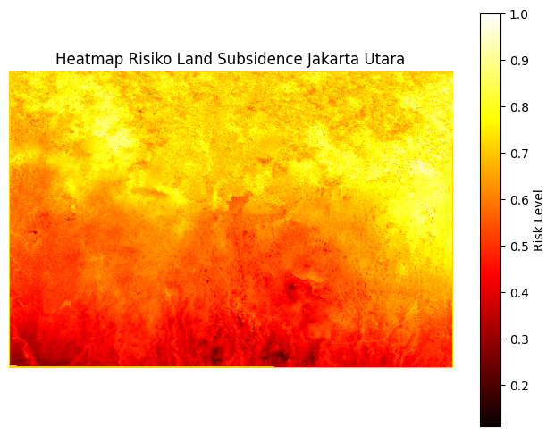

```python
#PEMBUATAN HEATMAP RISIKO

# Mengatur dimensi ukuran gambar peta yang akan ditampilkan (lebar 8 inci, tinggi 6 inci)
plt.figure(figsize=(8,6))

# Menampilkan array hasil perhitungan risiko menjadi peta heatmap digital dengan gradasi warna panas ('hot')
plt.imshow(risk, cmap='hot')

# Menampilkan batang gradasi warna di sebelah kanan peta sebagai penanda tingkatan level risiko
plt.colorbar(label='Risk Level')

# Memberikan judul teks utama di atas gambar heatmap
plt.title("Heatmap Risiko Land Subsidence Jakarta Utara")

# Mematikan tampilan sumbu X dan Y (garis tepi angka koordinat piksel) agar peta terlihat rapi
plt.axis('off')
```

#LAND SUBSIDENCE VS LAND USED

Output ini menganalisis hubungan antara land subsidence dan jenis penggunaan lahan menggunakan data RBI. Nilai penurunan tanah diekstraksi pada setiap poligon penggunaan lahan, kemudian divisualisasikan dalam bentuk boxplot untuk membandingkan karakteristik subsidence pada kawasan industri, permukiman, sawah, dan kategori penggunaan lahan lainnya.

```
Plotting: INDUSTRI_AR_25K
```

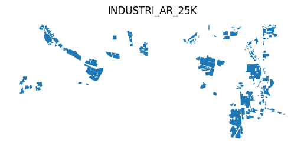

```
Plotting: PERUMAHAN_AR_25K
```

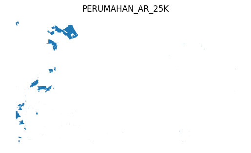

```
Plotting: PERMUKIMAN_AR_25K
```

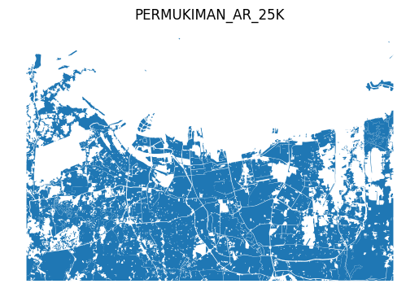

```
Plotting: SAWAH_AR_25K
```

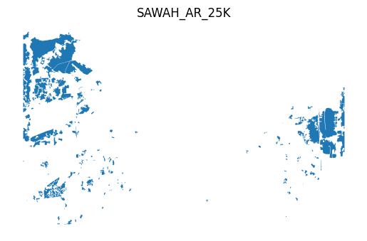

```python
#VISUALISASI AWAL LAYERS DARI FILE GDB

# Menggabungkan alamat folder dengan nama file Geodatabase (.gdb) RBI Jakarta Utara
gdb_path = os.path.join(base_path, "2022_RBI25K_JAKUT.gdb")

# Membuat daftar nama layer penggunaan lahan di dalam GDB yang ingin ditampilkan
layers_to_plot = [
    'INDUSTRI_AR_25K',    # Area Kawasan Industri
    'PERUMAHAN_AR_25K',   # Area Perumahan
    'PERMUKIMAN_AR_25K',  # Area Permukiman Umum
    'SAWAH_AR_25K'        # Area Pesawahan
]

# Melakukan perulangan untuk membaca dan menampilkan peta dari setiap layer di daftar
for layer_name in layers_to_plot:
    # Menampilkan teks nama layer yang sedang diproses di layar
    print(f"Plotting: {layer_name}")

    # Membaca layer vektor spasial tertentu dari file GDB ke dalam GeoDataFrame
    gdf = gpd.read_file(gdb_path, layer=layer_name)

    # Mengatur dimensi ukuran bingkai gambar grafik (lebar 6 inci, tinggi 6 inci)
    plt.figure(figsize=(6,6))

    # Menampilkan bentuk geometri objek vektor ke dalam plot grafik
    gdf.plot()

    # Memberikan teks judul di atas plot sesuai nama layer yang sedang aktif
    plt.title(layer_name)

    # Menghilangkan garis tepi dan angka koordinat peta agar tampilan lebih bersih
    plt.axis('off')

    # Memaksa matplotlib menyajikan visualisasi grafik saat ini sebelum lanjut ke iterasi berikutnya
    plt.show()
```

```python
# MEMBUKA BERKAS RASTER INSAR HASIL CROP

# Menentukan lokasi path file raster InSAR Jakarta Utara yang telah dipotong sebelumnya
raster_path = "insar_jakut_crop.tif"

# Membuka file berkas raster secara temporary sebagai variabel objek 'src'
src = rasterio.open(raster_path)

# Membaca data piksel permukaan tanah (band 1) ke dalam bentuk variabel matriks/array
insar_data = src.read(1)

# Menyimpan parameter transformasi spasial koordinat (geotransform) milik file raster tersebut
insar_transform = src.transform
```

```python
# PEMERIKSAAN ISI FILE GDB

# Mendefinisikan kembali letak berkas Geodatabase (.gdb) yang digunakan
gdb_path = "dataset/2022_RBI25K_JAKUT.gdb"

# Mengambil dan mendaftar seluruh nama layer yang tersedia di dalam file GDB tersebut
layers = fiona.listlayers(gdb_path)

# Mencetak daftar seluruh nama layer yang berhasil ditemukan ke layar
print(layers)
```

```
['ADMINISTRASI_AR_KABKOTA', 'ADMINISTRASI_LN_KABKOTA', 'ADMINISTRASI_AR_DESAKEL', 'ADMINISTRASI_AR_KECAMATAN', 'WADUK_AR_25K', 'TAMBAK_AR_25K', 'SUNGAI_AR_25K', 'RAWA_AR_25K', 'PESISIR_AR_25K', 'KOLAM_AR_25K', 'EMPANG_AR_25K', 'SUNGAI_LN_25K', 'BENDUNGAN_PT_25K', 'DANAU_AR_25K', 'PASIR_AR_25K', 'BET…
```

```python
# PENGGABUNGAN LAYER-LAYER GDB JADI SATU TABEL

# Membuat kamus (dictionary) untuk memetakan nama layer asli ke nama kategori yang lebih ringkas
layers_dict = {
    "INDUSTRI_AR_25K": "Industri",
    "PERMUKIMAN_AR_25K": "Permukiman",
    "PERUMAHAN_AR_25K": "Perumahan",
    "SAWAH_AR_25K": "Sawah"
}

# Menyediakan sebuah list kosong untuk menampung data dari setiap layer spasial
gdfs = []

# Melakukan perulangan untuk mengambil nama layer dan nama kategori barunya dari kamus data
for layer, kategori in layers_dict.items():
    # Membaca layer spasial dari berkas GDB ke dalam tabel temporary 'temp'
    temp = gpd.read_file(gdb_path, layer=layer)
    # Membuat kolom baru bernama 'kategori' dan mengisinya dengan label ringkas yang sesuai
    temp["kategori"] = kategori
    # Memasukkan tabel temporary tersebut ke dalam list penampung 'gdfs'
    gdfs.append(temp)

# Menggabungkan seluruh tabel spasial di dalam list menjadi satu kesatuan tabel besar (GeoDataFrame)
gdf = pd.concat(gdfs, ignore_index=True)
```

```python
# PENYELERASAN SISTEM KOORDINAT TABEL VEKTOR

# Mengubah sistem koordinat seluruh objek di tabel vektor (gdf) agar sesuai dengan sistem koordinat raster (src.crs)
gdf = gdf.to_crs(src.crs)
```

```python
# EKSTRAKSI PIXEL NILAI SUBSIDENCE PADA SETIAP POLIGON PENGGUNAAN LAHAN

# Membuat list kosong untuk mengumpulkan hasil rekaman data nilai piksel amatan
results = []

# Melakukan perulangan baris demi baris pada data tabel gabungan penggunaan lahan (gdf)
for idx, row in gdf.iterrows():
    # Mengambil bentuk geometri/poligon dari baris data yang sedang diperiksa saat ini
    geom = [row.geometry]

    # Menggunakan blok pengaman try-except untuk menghindari eror jika ada poligon di luar jangkauan peta raster
    try:
        # Memotong area gambar raster (src) sesuai bentuk geometri poligon lahan
        out_image, _ = mask(src, geom, crop=True)
        # Mengambil data piksel hasil potongan pada dimensi indeks ke-0 (band 1)
        data = out_image[0]

        # Menyaring dan membuang piksel yang bernilai kosong atau tidak memiliki data (NoData)
        data = data[data != src.nodata]
        # Menyaring dan membuang piksel yang memiliki nilai kerusakan sistem atau NaN
        data = data[~np.isnan(data)]

        # Melakukan perulangan untuk mengambil setiap nilai piksel penurunan tanah yang lolos seleksi
        for val in data:
            # Memasukkan nilai amatan berupa nama kategori lahan dan nilai penurunannya ke dalam list hasil
            results.append({
                "kategori": row["kategori"],  # Menyimpan informasi jenis penggunaan lahan
                "subsidence": val             # Menyimpan nilai laju pergeseran vertikal tanah tanah
            })

    # Jika terjadi kesalahan sistem spasial pada poligon saat ini, lewati dan lanjutkan ke baris berikutnya
    except:
        continue
```

[figure not shown]

```python
# PENYUSUNAN TABEL AKHIR DAN PEMBUATAN BOXPLOT

# Mengubah daftar list data amatan hasil ekstraksi (results) menjadi sebuah tabel terstruktur Pandas DataFrame
df = pd.DataFrame(results)

# Menyiapkan ruang gambar grafik visualisasi dengan lebar 10 inci dan tinggi 6 inci
plt.figure(figsize=(10,6))

# Membuat diagram kotak-garis (Boxplot) untuk melihat distribusi nilai sebaran data
df.boxplot(
    column="subsidence",            # Variabel numerik nilai laju penurunan tanah yang dianalisis pada sumbu Y
    by="kategori",                  # Pengelompokkan kotak diagram berdasarkan kolom kategori lahan pada sumbu X
    showfliers=True,                # Mengaktifkan opsi untuk menampilkan titik data pencilan (outliers) di luar grafik
    flierprops=dict(                # Mengatur visualisasi bentuk titik data pencilan (outliers)
        marker='o',                 # Mengubah bentuk penanda pencilan menjadi simbol lingkaran kecil
        markerfacecolor='red',      # Memberikan warna merah menyala pada bagian dalam simbol lingkaran pencilan
        markersize=4                # Menentukan ukuran diameter simbol lingkaran pencilan sebesar 4 poin
    )
)

# Memberikan teks judul utama tepat di bagian atas diagram boxplot
plt.title("Boxplot Subsidence Berdasarkan Penggunaan Lahan")

# Menghapus teks subjudul otomatis bawaan fungsi agar tampilan diagram tidak menumpuk
plt.suptitle("")

# Memberikan label nama keterangan untuk sumbu horizontal (X)
plt.xlabel("Kategori")

# Memberikan label nama keterangan serta satuan ukur data untuk sumbu vertikal (Y)
plt.ylabel("Subsidence (mm/year)")

# Menampilkan hasil visualisasi diagram boxplot akhir secara utuh di layar notebook
plt.show()
```

#STATISTIK SETIAP KECAMATAN

Output ini menyajikan analisis statistik penurunan muka tanah pada tingkat kecamatan di Jakarta Utara. Nilai minimum, maksimum, rata-rata, dan variasi subsidence dihitung dari raster InSAR untuk setiap wilayah administrasi, kemudian ditampilkan dalam bentuk grafik dan peta tematik guna mempermudah identifikasi kecamatan yang paling terdampak.

```python
# MEMBACA BATAS ADMINISTRASI KECAMATAN

# Membaca layer poligon administrasi kecamatan dari file Geodatabase (GDB)
kec = gpd.read_file(
    "dataset/2022_RBI25K_JAKUT.gdb",
    layer="ADMINISTRASI_AR_KECAMATAN"
)
```

```python
#MEMFILTER KECAMATAN DI JAKARTA UTARA

# Membuat daftar (list) nama-nama kecamatan yang berada di wilayah Jakarta Utara
kec_jakut = [
    "Penjaringan",
    "Tanjung Priok",
    "Koja",
    "Cilincing",
    "Pademangan",
    "Kelapa Gading"
]

# Menyaring tabel kecamatan agar hanya menyisakan nama kecamatan yang ada di dalam list kec_jakut
kec = kec[kec["NAMOBJ"].isin(kec_jakut)]

# Menampilkan nama-nama kecamatan unik yang lolos filter untuk memastikan tidak ada kekeliruan
kec["NAMOBJ"].unique()
```

```
array(['Penjaringan', 'Tanjung Priok', 'Koja', 'Cilincing', 'Pademangan',
       'Kelapa Gading'], dtype=object)
```

```python
#MENYAMAKAN SISTEM KOORDINAT

# Mengubah sistem koordinat (CRS) peta kecamatan agar sama persis dengan CRS milik data raster InSAR
kec = kec.to_crs(src.crs)
```

```python
# ESKTRASI NILAI PIXEL INSAR PER KECAMATAN

# Membuat list kosong untuk menampung seluruh baris data hasil ekstraksi nilai piksel
results_kec = []

# Melakukan perulangan baris demi baris untuk mengekstrak data di setiap poligon kecamatan
for idx, row in kec.iterrows():
    # Mengambil geometri/poligon dari kecamatan yang sedang diproses pada iterasi ini
    geom = [row.geometry]

    # Menggunakan blok pengaman try-except untuk mencegah error jika poligon berada di luar area raster
    try:
        # Memotong raster InSAR (src) menggunakan poligon batas kecamatan
        out_image, _ = mask(src, geom, crop=True)
        # Mengambil array piksel band 1 (indeks 0) dari hasil potongan raster
        data = out_image[0]

        # Membuang piksel kosong yang bernilai NoData dari array
        data = data[data != src.nodata]
        # Membuang piksel kosong yang bernilai NaN (Not a Number) dari array
        data = data[~np.isnan(data)]

        # Melakukan perulangan untuk memasukkan setiap nilai piksel yang valid ke dalam list hasil
        for val in data:
            results_kec.append({
                "kecamatan": row["NAMOBJ"],  # Menyimpan nama kecamatan asal piksel tersebut
                "subsidence": val            # Menyimpan nilai laju pergeseran vertikal tanah tanah
            })

    # Jika terjadi error spasial saat memotong poligon kecamatan ini, abaikan dan lanjut ke kecamatan berikutnya
    except:
        continue
```

```python
# PERHITUNGAN STATISTIK ZONA

# Mengubah list hasil ekstraksi (results_kec) menjadi bentuk tabel terstruktur Pandas DataFrame
df_kec = pd.DataFrame(results_kec)

# Mengelompokkan data berdasarkan kolom 'kecamatan', lalu menghitung nilai mean, min, max, dan standar deviasi dari kolom 'subsidence'
stat_kec = df_kec.groupby("kecamatan")["subsidence"].agg([
    "mean", "min", "max", "std"
]).reset_index() # Mengembalikan kolom 'kecamatan' menjadi kolom biasa (bukan indeks tabel)

# Menampilkan tabel ringkasan hasil perhitungan statistik zonal per kecamatan ke layar
stat_kec
```

|  | kecamatan | mean | min | max | std |
| --- | --- | --- | --- | --- | --- |
| 0 | Cilincing | -0.013775 | -0.072992 | 0.025016 | 0.018674 |
| 1 | Kelapa Gading | 0.032188 | 0.006999 | 0.054710 | 0.010964 |
| 2 | Koja | 0.007326 | -0.022199 | 0.023838 | 0.007613 |
| 3 | Pademangan | 0.032736 | -0.007242 | 0.049665 | 0.007973 |
| 4 | Penjaringan | 0.007659 | -0.046319 | 0.053837 | 0.015381 |
| 5 | Tanjung Priok | 0.028126 | -0.018727 | 0.059501 | 0.014941 |

[figure not shown]

```python
# VISUALISASI GRAFIK SUBSIDENCE PER KECAMATAN

plt.figure(figsize=(10,6))

plt.bar(stat_kec["kecamatan"], stat_kec["min"])

plt.xticks(rotation=45)
plt.xlabel("Kecamatan")
plt.ylabel("Mean Subsidence (mm/year)")
plt.title("Subsidence Tertinggi per Kecamatan Jakarta Utara")

plt.show()
```

```python
# MENGGABUNGKAN DATA STATISTIK KE DATA SPASIAL

# Menggabungkan tabel spasial kecamatan (kec) dengan tabel statistik (stat_kec) berdasarkan kecocokan nama kecamatan
kec_map = kec.merge(
    stat_kec,
    left_on="NAMOBJ",       # Kolom kunci nama kecamatan di tabel spasial (kec)
    right_on="kecamatan"    # Kolom kunci nama kecamatan di tabel statistik (stat_kec)
)
```

[figure not shown]

```python
# VISUALISASI PETA LAJU PENURUNAN SUBSIDENCE

# Mengatur dimensi bingkai peta yang akan ditampilkan (lebar 10 inci, tinggi 8 inci)
plt.figure(figsize=(10,8))

# Menampilkan peta poligon kecamatan dengan pewarnaan otomatis berdasarkan nilai rata-rata pergeseran tanah
kec_map.plot(
    column="mean",          # Kolom acuan gradasi warna peta (nilai rata-rata pergeseran tanah)
    cmap="RdBu",            # Menggunakan skema warna Red-Blue (Merah untuk penurunan, Biru untuk pengangkatan)
    legend=True,            # Menampilkan batang legenda skala nilai di samping peta
    edgecolor="black"       # Memberikan garis tepi berwarna hitam pada setiap batas poligon kecamatan
)

# Memberikan judul teks di atas gambar peta spasial kecamatan
plt.title("Peta Rata-rata Subsidence Jakarta Utara (mm/tahun)")

# Menghilangkan garis sumbu koordinat piksel agar peta terlihat rapi dan bersih
plt.axis('off')

# Menampilkan hasil visualisasi peta akhir ke layar
plt.show()
```

#PREDIKSI LAND SUBSIDENCE 10 TAHUN KEDEPAN

Output ini memberikan estimasi akumulasi penurunan muka tanah selama sepuluh tahun mendatang berdasarkan asumsi laju subsidence saat ini tetap konstan. Hasil prediksi disajikan dalam bentuk raster dan peta klasifikasi risiko untuk membantu memahami potensi dampak jangka panjang terhadap wilayah Jakarta Utara.

```python
# MEMBACA DAT RASTER INSAR

# Mendefinisikan path lokasi file raster InSAR Jakarta Utara hasil pemotongan sebelumnya
raster_path = "insar_jakut_crop.tif"

# Membuka file raster secara temporary menggunakan variabel objek 'src'
with rasterio.open(raster_path) as src:
    # Membaca data piksel permukaan tanah band 1 ke dalam array numpy
    insar = src.read(1)
    # Menyalin profil metadata asli raster (seperti koordinat, CRS, tipe data) untuk pembuatan file baru
    profile = src.profile
```

```python
# MENGHITUNG PREDIKSI AKUMULASI 10 TAHUN

# Mengalikan nilai laju amlesan tahunan (InSAR) dengan angka 10 untuk memproyeksikan total penurunan 10 tahun ke depan
pred_10yr = insar * 10
```

```python
# MENYIMPAN HASIL PREDIKSI KE FILE GEOTIFF BARU

# Mendefinisikan path lokasi dan nama file baru untuk menyimpan hasil proyeksi 10 tahun
output_path = "prediksi_10tahun.tif"

# Membuat file raster baru di Drive dengan mode write ('w') menggunakan parameter metadata 'profile' yang asli
with rasterio.open(output_path, 'w', **profile) as dst:
    # Menuliskan array data hasil prediksi 10 tahun ke dalam band 1 file tersebut
    dst.write(pred_10yr, 1)
```

```
WARNING:rasterio._env:CPLE_IllegalArg in prediksi_10tahun.tif: BLOCKXSIZE can only be used with TILED=YES
```

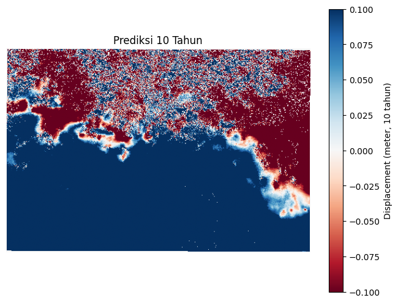

```python
# VISUALISASI PETA 10 TAHUN KEDEPAN

# Mengatur dimensi ukuran bingkai peta (lebar 8 inci, tinggi 6 inci)
plt.figure(figsize=(8,6))

# Menampilkan peta prediksi kontinu menggunakan skema warna Red-Blue dengan batas rentang nilai fungsional -0.1 sampai 0.1 meter
plt.imshow(pred_10yr, cmap='RdBu', vmin=-0.1, vmax=0.1)

# Menampilkan batang gradasi warna di samping peta dengan keterangan label satuannya
plt.colorbar(label='Displacement (meter, 10 tahun)')

# Memberikan judul teks utama di bagian atas gambar peta
plt.title("Prediksi 10 Tahun")

# Mematikan tampilan garis tepi sumbu X dan Y agar tampilan peta bersih
plt.axis('off')

# Menampilkan gambar visualisasi visual peta prediksi kontinu tersebut ke layar
plt.show()
```

```python
# KLASIFIKASI TINGKAT RISIKO

# Membuat matriks kosong baru berisi angka nol dengan dimensi baris dan kolom yang persis sama seperti matriks 'pred_10yr'
risk = np.zeros_like(pred_10yr)

# Mengisi matriks 'risk' dengan nilai 1 (Kelas Rendah) untuk area yang penurunannya lebih dari -0.1 meter (amblesan tipis / aman)
risk[pred_10yr > -0.1] = 1

# Mengisi matriks 'risk' dengan nilai 2 (Kelas Sedang) untuk area dengan penurunan antara -0.3 meter sampai dengan -0.1 meter
risk[(pred_10yr <= -0.1) & (pred_10yr > -0.3)] = 2

# Mengisi matriks 'risk' dengan nilai 3 (Kelas Tinggi) untuk area yang mengalami penurunan sangat dalam, yaitu <= -0.3 meter
risk[pred_10yr <= -0.3] = 3
```

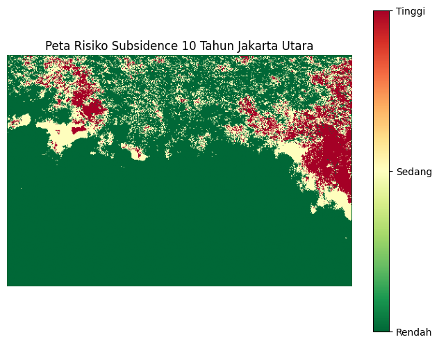

```python
# VISUALISASI KLASIFIKASI TINGKAT RISIKO

# Mengatur kembali dimensi ukuran bingkai peta klasifikasi (lebar 8 inci, tinggi 6 inci)
plt.figure(figsize=(8,6))

# Menampilkan data zonasi risiko menggunakan warna diskret Red-Yellow-Green Terbalik (Hijau = Rendah, Merah = Tinggi)
plt.imshow(risk, cmap='RdYlGn_r')

# Memanggil fungsi pembuat komponen batang legenda warna dan menyimpannya ke variabel 'cbar'
cbar = plt.colorbar()

# Mengatur posisi penanda angka (ticks) pada batang legenda tepat di angka kelas 1, 2, dan 3
cbar.set_ticks([1, 2, 3])

# Mengubah teks label angka pada legenda menjadi label kategori deskriptif ("Rendah", "Sedang", "Tinggi")
cbar.set_ticklabels(["Rendah", "Sedang", "Tinggi"])

# Memberikan judul teks utama di atas peta klasifikasi zonasi risiko
plt.title("Peta Risiko Subsidence 10 Tahun Jakarta Utara")

# Mematikan tampilan sumbu koordinat piksel agar gambar peta rapi
plt.axis('off')

# Menampilkan visualisasi peta zonasi risiko akhir ke layar notebook
plt.show()
```

#PENURUNAN MUKA AIR TANAH

Output ini mengolah data sumur pantau untuk menghitung perubahan muka air tanah pada periode pengamatan tertentu. Analisis dilakukan dengan membandingkan nilai MAT antar waktu sehingga diperoleh besaran penurunan muka air tanah pada setiap lokasi pengamatan yang dapat digunakan sebagai indikator tekanan terhadap sistem akuifer.

```python
# MENYUSUN PATH FILE DATA

# Menyimpan string nama file excel data muka air tanah sumur pantau untuk periode tahun 2023
FILE_2023 = 'data-kedalaman-muka-air-tanah-pada-sumur-pantau-di-5-wilayah-2023-komponen-data.xls'

# Menyimpan string nama file excel data muka air tanah sumur pantau untuk periode tahun 2024
FILE_2024 = 'data-kedalaman-muka-air-tanah-pada-sumur-pantau-di-5-(lima)-wilayah-2024-komponen-data.xls'

# Menggabungkan folder 'dataset' dengan nama file 2023 menjadi path lengkap sistem secara aman
path_2023 = os.path.join(PATH_PROJEK, FILE_2023)

# Menggabungkan folder 'dataset' dengan nama file 2024 menjadi path lengkap sistem secara aman
path_2024 = os.path.join(PATH_PROJEK, FILE_2024)
```

```python
# MEMBACA DATA DAN FILTER WILAYAH

# Membaca tabel pertama ([0]) dari file HTML/Excel tahun 2023 ke dalam DataFrame
df_2023_raw = pd.read_html(path_2023)[0]

# Membaca tabel pertama ([0]) dari file HTML/Excel tahun 2024 ke dalam DataFrame
df_2024_raw = pd.read_html(path_2024)[0]

# Menyimpan nama kolom lokasi sumur ke dalam sebuah variabel string
kolom_lokasi = 'lokasi'

# Menyaring data tahun 2023 agar hanya mengambil baris yang mengandung teks 'JAKARTA UTARA'
df_2023_ju = df_2023_raw[df_2023_raw[kolom_lokasi].str.contains('JAKARTA UTARA', case=False, na=False)].copy()

# Menyaring data tahun 2024 agar hanya mengambil baris yang mengandung teks 'JAKARTA UTARA'
df_2024_ju = df_2024_raw[df_2024_raw[kolom_lokasi].str.contains('JAKARTA UTARA', case=False, na=False)].copy()
```

```python
# ESKTRAK BULAN DAN SELEKSI DATA

# Mengubah digit bulan 2023 menjadi string, membuang spasi, dan menambahkan angka 0 di depan jika hanya 1 digit (misal: '5' -> '05')
df_2023_ju['bulan_clean'] = df_2023_ju['bulan'].astype(str).str.strip().str.zfill(2)

# Memotong 2 karakter terakhir dari kolom periode_data tahun 2024 untuk mengambil digit bulannya saja
df_2024_ju['bulan_clean'] = df_2024_ju['periode_data'].astype(str).str[-2:]

# Menentukan parameter bulan filter untuk bulan Mei ('05')
BULAN_FILTER = '05'

# Menyaring data Jakarta Utara tahun 2023 khusus untuk pengamatan di bulan Mei
df_2023_mei = df_2023_ju[df_2023_ju['bulan_clean'] == BULAN_FILTER].copy()

# Menyaring data Jakarta Utara tahun 2024 khusus untuk pengamatan di bulan Mei
df_2024_mei = df_2024_ju[df_2024_ju['bulan_clean'] == BULAN_FILTER].copy()

# Menghapus baris duplikat berdasarkan nama lokasi di bulan Mei 2023 dengan mempertahankan data urutan pertama
df_2023_terpilih = df_2023_mei.drop_duplicates(subset=[kolom_lokasi], keep='first').copy()

# Menghapus baris duplikat berdasarkan nama lokasi di bulan Mei 2024 dengan mempertahankan data urutan pertama
df_2024_terpilih = df_2024_mei.drop_duplicates(subset=[kolom_lokasi], keep='first').copy()

# Mencetak jumlah total sumur unik yang berhasil difilter untuk bulan Mei tahun 2023 dan 2024
print(f"Jumlah sumur unik Bulan Mei -> Tahun 2023: {len(df_2023_terpilih)} | Tahun 2024: {len(df_2024_terpilih)}")
```

```
Jumlah sumur unik Bulan Mei -> Tahun 2023: 3 | Tahun 2024: 3
```

```python
# STANDARISASI NAMA LOKASI SUMUR

# Membuat fungsi untuk membersihkan teks nama lokasi agar formatnya seragam antar tahun
def bersihkan_nama_eksak(nama):
    # Jika baris data kosong (NaN), kembalikan string kosong
    if pd.isna(nama):
        return ""
    # Mengubah teks menjadi huruf kapital semua serta menghapus karakter titik dan koma
    nama_clean = str(nama).upper().replace('.', '').replace(',', '')
    # Memperbaiki kekeliruan ketik teks ganda 'PLUIT PLUIT' menjadi satu kata 'PLUIT'
    nama_clean = nama_clean.replace('PLUIT PLUIT', 'PLUIT')
    # Memotong spasi berlebih di ujung teks dan menyatukan kata agar tidak ada spasi ganda di tengah kalimat
    return " ".join(nama_clean.split()).strip()

# Menerapkan fungsi pembersihan nama pada kolom lokasi untuk data terpilih tahun 2023
df_2023_terpilih['lokasi_clean'] = df_2023_terpilih[kolom_lokasi].apply(bersihkan_nama_eksak)

# Menerapkan fungsi pembersihan nama pada kolom lokasi untuk data terpilih tahun 2024
df_2024_terpilih['lokasi_clean'] = df_2024_terpilih[kolom_lokasi].apply(bersihkan_nama_eksak)
```

```python
# KONVERSI NILAI SUMUR KE MAT

# Menyimpan nama kolom muka air tanah ke dalam sebuah variabel string
kolom_mat = 'muka_air_tanah'

# Membuat fungsi untuk mengubah format penulisan angka string yang salah ketik menjadi float desimal riil
def ekstrak_nilai_mat_riil(nilai):
    # Jika data kosong (NaN), kembalikan nilai NaN dari numpy
    if pd.isna(nilai):
        return np.nan

    # Menghapus spasi di ujung teks dan mengganti tanda hubung/minus menjadi karakter spasi biasa
    val_str = str(nilai).strip().replace('-', ' ')
    # Memisahkan teks menjadi daftar kata/angka berdasarkan karakter spasi
    parts = val_str.split()

    # Jika teks terpisah menjadi 2 bagian angka atau lebih (contoh: '44 92' akibat salah ketik spasi/minus)
    if len(parts) >= 2:
        # Menggabungkan angka bagian pertama dan kedua dengan dipisahkan karakter titik (.) menjadi format desimal
        angka_gabung = f"{parts[0]}.{parts[1]}"
        # Mengubah teks gabungan tersebut menjadi tipe data angka pecahan (float)
        return float(angka_gabung)
    # Jika teks hanya berupa satu bagian angka utuh
    elif len(parts) == 1:
        # Mengubah teks angka tersebut langsung menjadi numerik (jika gagal/error akan diubah jadi NaN)
        return pd.to_numeric(parts[0], errors='coerce')

    # Jika tidak memenuhi kondisi di atas, kembalikan nilai kosong (NaN)
    return np.nan

# Menerapkan fungsi konversi angka MAT desimal pada tabel data tahun 2023
df_2023_terpilih['mat_clean'] = df_2023_terpilih[kolom_mat].apply(ekstrak_nilai_mat_riil)

# Menerapkan fungsi konversi angka MAT desimal pada tabel data tahun 2024
df_2024_terpilih['mat_clean'] = df_2024_terpilih[kolom_mat].apply(ekstrak_nilai_mat_riil)
```

```python
# PENGGABUNGAN DAN PENGHITUNGAN SELISIH MAT

# Memilih kolom nama lokasi dan MAT tahun 2023 saja, serta mengubah nama kolom MAT agar spesifik tahun 2023
tabel_2023 = df_2023_terpilih[['lokasi_clean', 'mat_clean']].rename(columns={'mat_clean': 'mat_mei_2023'})

# Memilih kolom nama lokasi dan MAT tahun 2024 saja, serta mengubah nama kolom MAT agar spesifik tahun 2024
tabel_2024 = df_2024_terpilih[['lokasi_clean', 'mat_clean']].rename(columns={'mat_clean': 'mat_mei_2024'})

# Menggabungkan kedua tabel menggunakan metode 'inner join' berdasarkan kesamaan nama lokasi yang sudah bersih
df_final_komparasi = pd.merge(tabel_2023, tabel_2024, on='lokasi_clean', how='inner')

# Menghitung selisih fluktuasi muka air tanah dengan rumus: Nilai Tahun 2024 dikurangi Nilai Tahun 2023
df_final_komparasi['perubahan_mat'] = df_final_komparasi['mat_mei_2024'] - df_final_komparasi['mat_mei_2023']

# Menampilkan hasil akhir tabel perbandingan muka air tanah antar tahun yang sudah bersih ke layar
df_final_komparasi
```

|  | lokasi_clean | mat_mei_2023 | mat_mei_2024 | perubahan_mat |
| --- | --- | --- | --- | --- |
| 0 | KANTOR KELURAHAN PLUIT JAKARTA UTARA | 23.98 | 23.48 | -0.50 |
| 1 | KANTOR WALIKOTA JAKARTA UTARA | 5.66 | 5.88 | 0.22 |
| 2 | GEDUNG JUDO KELAPA GADING JAKARTA UTARA | 13.60 | 14.10 | 0.50 |

#LAND SUBSIDENCE VS PENURUNAN MAT

Output ini mengevaluasi keterkaitan antara penurunan muka tanah dan perubahan muka air tanah di Jakarta Utara. Data subsidence dari InSAR dibandingkan dengan data sumur pantau untuk melihat apakah lokasi dengan penurunan muka air tanah yang lebih besar juga menunjukkan laju subsidence yang lebih tinggi.

```python
# HUBUNGKAN LOKASI KECAMATAN KE SUMUR PANTAU

# Membuat kamus (dictionary) untuk memasangkan nama stasiun sumur pantau dengan wilayah kecamatannya
mapping_kecamatan = {
    'KANTOR KELURAHAN PLUIT JAKARTA UTARA': 'Penjaringan',
    'KANTOR WALIKOTA JAKARTA UTARA': 'Tanjung Priok',
    'GEDUNG JUDO KELAPA GADING JAKARTA UTARA': 'Kelapa Gading'
}

# Membuat kolom baru 'kecamatan' dengan mencocokkan nilai kolom 'lokasi_clean' menggunakan acuan dictionary
df_final_komparasi['kecamatan'] = df_final_komparasi['lokasi_clean'].map(mapping_kecamatan)

# Menampilkan kolom lokasi, nama kecamatan, dan nilai perubahan muka air tanah (MAT) dari dataframe
df_final_komparasi[['lokasi_clean', 'kecamatan', 'perubahan_mat']]
```

|  | lokasi_clean | kecamatan | perubahan_mat |
| --- | --- | --- | --- |
| 0 | KANTOR KELURAHAN PLUIT JAKARTA UTARA | Penjaringan | -0.50 |
| 1 | KANTOR WALIKOTA JAKARTA UTARA | Tanjung Priok | 0.22 |
| 2 | GEDUNG JUDO KELAPA GADING JAKARTA UTARA | Kelapa Gading | 0.50 |

```python
# GABUNGKAN DATA DENGAN LAND SUBSIDENCE MAKSIMAL

# Menggabungkan dataframe data sumur pantau (df_final_komparasi) dengan dataframe statistik InSAR kecamatan (stat_kec)
df_output7 = pd.merge(
    df_final_komparasi,             # Dataframe kiri yang berisi data fluktuasi muka air tanah sumur pantau
    stat_kec[['kecamatan', 'min']], # Dataframe kanan yang hanya diambil kolom nama kecamatan dan nilai laju subsidence minimum
    on='kecamatan',                 # Kolom acuan atau kunci penggabungan yang nilainya harus sama di kedua tabel
    how='inner'                     # Metode penggabungan inner join (hanya mempertahankan baris dengan kecamatan yang cocok di kedua tabel)
)

# Membuat kolom baru bernama 'subsidence_min_mm' dengan mengalikan kolom 'min' dengan angka 1000
# Berfungsi untuk mengonversi satuan data dari meter/tahun menjadi milimeter/tahun (mm/tahun)
df_output7['subsidence_min_mm'] = df_output7['min'] * 1000

# Menampilkan tabel hasil akhir dengan hanya memunculkan kolom-kolom utama yang sudah siap digunakan untuk plotting grafik
df_output7[['kecamatan', 'lokasi_clean', 'perubahan_mat', 'subsidence_min_mm']]
```

|  | kecamatan | lokasi_clean | perubahan_mat | subsidence_min_mm |
| --- | --- | --- | --- | --- |
| 0 | Penjaringan | KANTOR KELURAHAN PLUIT JAKARTA UTARA | -0.50 | -46.319473 |
| 1 | Tanjung Priok | KANTOR WALIKOTA JAKARTA UTARA | 0.22 | -18.727251 |
| 2 | Kelapa Gading | GEDUNG JUDO KELAPA GADING JAKARTA UTARA | 0.50 | 6.999273 |

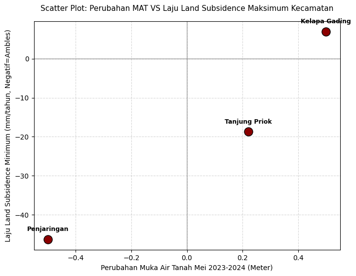

```python
#VISUALISASI HUBUNGAN PERUBAHAN MAT DENGAN LAND SUBSIDENCE

# Mengatur dimensi rasio ukuran jendela gambar grafik plot (lebar 8 inci dan tinggi 6 inci)
plt.figure(figsize=(8, 6))

# Membuat diagram titik (scatter plot) untuk memetakan sebaran data korelasi MAT vs laju amblesan maksimum
plt.scatter(
    df_output7['perubahan_mat'],               # Parameter nilai sumbu horizontal / X (fluktuasi air tanah dalam meter)
    df_output7['subsidence_min_mm'],           # Parameter nilai sumbu vertikal / Y (laju amlesan maksimum dalam mm/tahun)
    color='darkred',                           # Mengubah warna marker lingkaran menjadi merah tua (darkred)
    s=150,                                     # Menentukan ukuran besar diameter marker lingkaran sebesar 150 poin
    edgecolors='black',                        # Memberikan garis lingkaran tepi berwarna hitam pada marker titik
    zorder=3                                   # Memposisikan layer titik sampel agar berada di susunan paling depan objek grafik
)

# Melakukan perulangan indeks (i) dan teks (txt) untuk menempelkan label nama kecamatan pada tiap titik plot
for i, txt in enumerate(df_output7['kecamatan']):
    plt.annotate(
        txt,                                   # Isi teks label yang akan dimunculkan (nama kecamatan)
        (df_output7['perubahan_mat'].iloc[i], df_output7['subsidence_min_mm'].iloc[i]), # Koordinat lokasi penempatan teks label
        textcoords="offset points",            # Memilih sistem koordinat pergeseran teks berbasis poin (offset)
        xytext=(0,12),                         # Menggeser posisi teks secara vertikal sejauh 12 poin tepat di atas titik koordinat
        ha='center',                           # Mengatur perataan posisi teks secara horizontal agar berada di tengah (center)
        fontweight='bold',                     # Mengubah jenis ketebalan teks label menjadi cetak tebal (bold)
        fontsize=9                             # Menetapkan ukuran besar huruf teks label sebesar 9 poin
    )

# Mengatur komponen kelengkapan anotasi dan kosmetik pada diagram grafik scatter plot
plt.title('Scatter Plot: Perubahan MAT VS Laju Land Subsidence Maksimum Kecamatan', fontsize=11, pad=15)
plt.xlabel('Perubahan Muka Air Tanah Mei 2023-2024 (Meter)', fontsize=10)
plt.ylabel('Laju Land Subsidence Minimum (mm/tahun, Negatif=Ambles)', fontsize=10)

# Mengaktifkan garis grid penolong putus-putus dengan tingkat transparansi 50% di latar belakang (zorder=1)
plt.grid(True, linestyle='--', alpha=0.5, zorder=1)

# Membuat garis bantu horizontal (X) tegas tepat pada nilai koordinat Y = 0 berwarna abu-abu
plt.axhline(0, color='gray', linestyle='-', alpha=0.5)

# Membuat garis bantu vertikal (Y) tegas tepat pada nilai koordinat X = 0 berwarna abu-abu
plt.axvline(0, color='gray', linestyle='-', alpha=0.5)

# Menyajikan visualisasi grafik diagram sebaran korelasi akhir secara utuh di layar notebook
plt.show()
```